# #Factchecks met BRON

author: Romano Londt  
date: 31-01-2019

### Inhoud

- Dataset
- Is de randstad welvarender dan de rest van Nederland?  
  – Vraagstelling  
  – Operationalisatie  
  – Conclusie
- Veroorzaken pakketbezorgers onveilige situaties in 30km zones?  
  – Vraagstelling  
  – Operationalisatie  
  – Conclusie

### Dataset

- BRON  
  – Verkeersongevallen beschikbaar gesteld door Rijkswaterstaat
- Voorbewerking  
  – R-script met functies  
  – Explorative analysis (Verkennend onderzoek)  
  – Shiny

.

[output not shown]

### Verkennend onderzoek: aantallen ongevallen per maand

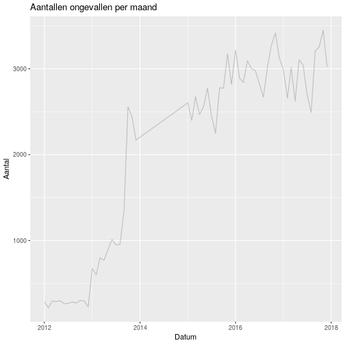

### Is de randstad welvarender dan de rest van Nederland?

- [CBS](https://www.cbs.nl/nl-nl/nieuws/2007/30/inwoners-Randstad-verdienen-het-meest)
- wordt de stelling ook vanuit het BRON-bestand worden ondersteund

### Verkennend onderzoek

**Wat is de statistische verdeling van de leeftijd**

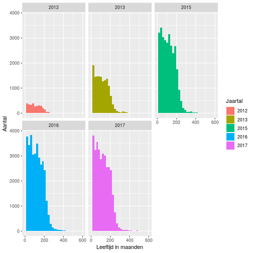

*Poisson, behandelen als normale verdeling gezien de aantallen*  
**Spreiding wordt wel steeds groter**

### Verkennend onderzoek: is er onderscheid per provincie

```r
df_prov <- df_explorative %>%
  group_by(jaar_integer, PVE_NAAM) %>%
  summarise(gemiddelde_leeftijd = mean(leeftijd_voertuig))

df_prov <- right_join(nld.1, df_prov, by = c("NAME_1" = "PVE_NAAM"))

ggplot(data = df_prov) +
  geom_sf(aes(fill = gemiddelde_leeftijd))+
  scale_fill_gradient(low = "#ffffe6", high = "#990000")#+
  #facet_wrap(~jaar_integer,ncol = 3)
```

### Verkennend onderzoek: is er onderscheid per provincie

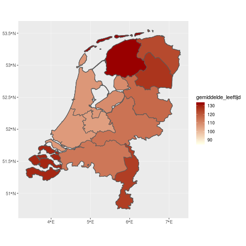

**Er is verschil tussen de provincies**

### Operationalisatie(1)

**Is de populatie binnen de randstad welvarender dan de rest van Nederland?**

*Randstad*

- Provincies
  - Zuid-Holland
  - Noord-Holland
  - Utrecht

*Welvarender*

- Hebben gemiddeld jongere voertuigen

### Operationalisatie(2)

*Ho*

- gemiddelde leeftijd van de voertuigen betrokken is gelijk verdeeld over Nederland

*H1*

- gemiddelde leeftijd van de voertuigen betrokken is in de randstad lager

Toetsen door middel van een T-Toets voor twee onafhankelijke steekproeven

- Eenzijdig toetsen
- Alternative = less

### Bewerking dataset

```r
randstad <- c("Zuid-Holland", "Noord-Holland", "Utrecht")
df_randstad <- df_leeftijd  %>%
  mutate(randstad = PVE_NAAM %in% randstad) %>%
  filter(randstad==TRUE)

df_rest <- df_leeftijd  %>%
  mutate(randstad = PVE_NAAM %in% randstad) %>%
  filter(randstad==FALSE)
```

### Beantwoording Visueel(tabel)

```r
data.frame(categorie=c("Leeftijd overig","Leeftijd Randstad")
, gemiddelde=c(mean(df_rest$leeftijd_voertuig), mean(df_randstad$leeftijd_voertuig))
, stddev=c(sd(df_rest$leeftijd_voertuig), sd(df_randstad$leeftijd_voertuig)))
```

```
          categorie gemiddelde   stddev
1   Leeftijd overig   116.4835 75.93038
2 Leeftijd Randstad   103.7824 73.07885
```

### Beantwoording Visueel(density-plot)

```r
ggplot()+
  geom_density(data=df_rest, aes(x=leeftijd_voertuig, fill="leeftijd overig"), alpha=0.25)+
  geom_density(data=df_randstad, aes(x=leeftijd_voertuig, fill="leeftijd randstad"), alpha=0.25)+
  geom_vline(aes(xintercept = mean(df_rest$leeftijd_voertuig), color="leeftijd overig"))+
  geom_vline(aes(xintercept = mean(df_randstad$leeftijd_voertuig), color="leeftijd randstad"))+
  labs(color="", fill="")+
  xlab(label = "Leeftijd voertuig in maanden")+
  ylab(label = "Dichtheidsfunctie")+
  xlim(c(0, 300))
```

### Beantwoording Visueel(density-plot)

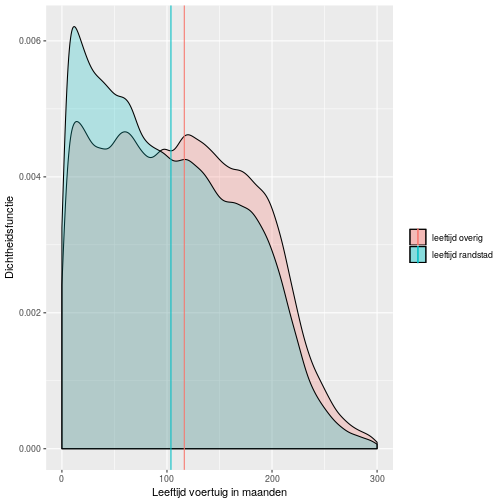

### Beantwoording Visueel(statistische functie)

```r
ggplot(NULL, aes(x, colour= Legenda)) +
  stat_function(data = data.frame(x = 0:600, Legenda=factor(1)), fun = dnorm, args = list(mean = mean(df_rest$leeftijd_voertuig), sd = sd(df_rest$leeftijd_voertuig))) +
  stat_function(data = data.frame(x = 0:600, Legenda=factor(2)), fun = dnorm, args = list(mean = mean(df_randstad$leeftijd_voertuig), sd = sd(df_randstad$leeftijd_voertuig))) +
  scale_colour_manual(values = c("red", "blue"), labels = c("Rest", "Randstad"))+
  xlim(c(0, 300))
```

### Beantwoording Visueel(statistische functie)

[figure not shown]

### Beantwoording Statistisch

```r
t.test(df_randstad$leeftijd_voertuig, df_rest$leeftijd_voertuig, mu=0, alternative = "less", conf.level = 0.99)
```

```
    Welch Two Sample t-test

data:  df_randstad$leeftijd_voertuig and df_rest$leeftijd_voertuig
t = -59.482, df = 482680, p-value < 2.2e-16
alternative hypothesis: true difference in means is less than 0
99 percent confidence interval:
      -Inf -12.20441
sample estimates:
mean of x mean of y
 103.7824  116.4835
```

### Conclusie

**Op basis van de BRON dataset is te herleiden dat voertuigen in de randstad gemiddeld jonger zijn dan in de rest van Nederland. Hieruit kan worden afgeleid dat de Randstad welvarender is dan de rest van het land.**

### Vraagstelling

https://nos.nl/artikel/2264908-pakketbezorgers-veroorzaken-onveilige-verkeerssituaties.html

### Operationalisatie(1)

*Veroorzaken pakketbezorgers onveilige situaties in 30km zones?*

**hoe herkennen we pakketbezorgers?**

- footprint van de voertuigen is groter dan normale auto's
- als er meer ongevallen gebeuren met pakketbezorgers zal de gemiddelde footprint stijgen

**30 kilometer zone's**

- maximum snelheid = 30
- binnen de bebouwde kom

### Operationalisatie(2)

*Ho*

- footprint van de voertuigen die ongelukken veroorzaken binnen de bebouwde kom waar een maximumsnelheid geld is de afgelopen jaren gelijk gebleven

*H1*

- footprint van de voertuigen die ongelukken veroorzaken binnen de bebouwde kom waar een maximumsnelheid geld is de afgelopen jaren groter geworden

### Antwoord - visueel (1)

```r
df_hyp <- df_totaal %>%
  filter(!is.na(BREEDTE) & !is.na(LENGTE)) %>%
  mutate(footprint = BREEDTE*LENGTE ) %>%
  mutate(jaar = year(DATUM))

ggplot(df_hyp, aes(x=jaar, y=footprint)) +
  geom_boxplot(aes(group=jaar))+
  scale_y_continuous("footprint van de voertuigen", labels = comma) +
  scale_x_discrete("jaartal", breaks=c(2005:2018), labels=c(2005:2018) )
```

### Antwoord - visueel (1)

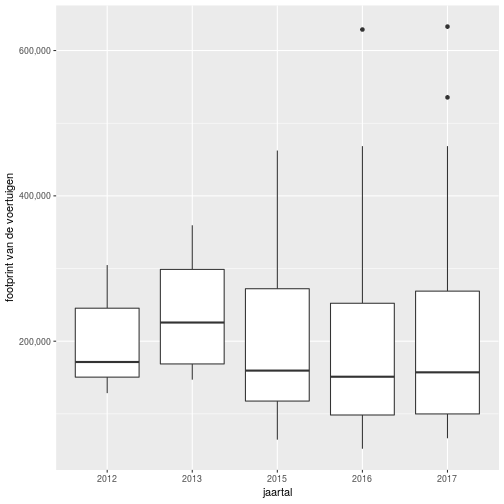

- daling zichtbaar in de laatste twee jaren ten opzichte van de rest van de historie
- **Geen bewijs voor de stelling**

### Antwoord - statistisch

Jaartallen vergelijken

- meerdere jaartallen(groepen)
- beoordelen of de gemiddelden van deze groepen significant van elkaar afwijken
  - **ANOVA**

```r
df_aov <- df_hyp %>%
  mutate(jaar2 = as.integer(year(DATUM))) %>%
  filter(jaar2 >= 2010 )

# Compute the analysis of variance
res.aov <- aov(footprint ~ jaar, data = df_aov)
summary(res.aov)
```

### Antwoord - statistisch

Jaartallen vergelijken

- ANOVA + Tukey
- http://www.sthda.com/english/wiki/one-way-anova-test-in-r

```
              Df    Sum Sq   Mean Sq F value Pr(>F)
jaar           4 1.016e+11 2.540e+10   2.678 0.0303 *
Residuals   1782 1.690e+13 9.483e+09
---
Signif. codes:  0 '***' 0.001 '**' 0.01 '*' 0.05 '.' 0.1 ' ' 1
```

**Significant verschil tussen groepen(jaren)**

### Antwoord - statistisch

```
  Tukey multiple comparisons of means
    95% family-wise confidence level

Fit: aov(formula = footprint ~ jaar, data = df_aov)

$jaar
                diff         lwr        upr     p adj
2013-2012  33800.863  -45652.194 113253.920 0.7732578
2015-2012  -1739.344  -61004.007  57525.319 0.9999907
2016-2012 -15913.914  -74900.397  43072.569 0.9479088
2017-2012  -7631.658  -66618.141  51354.825 0.9966664
2015-2013 -35540.207  -91140.996  20060.582 0.4063155
2016-2013 -49714.777 -105018.960   5589.405 0.1016702
2017-2013 -41432.521  -96736.704  13871.662 0.2446757
2016-2015 -14174.570  -30238.961   1889.821 0.1132132
2017-2015  -5892.314  -21956.705  10172.077 0.8547292
2017-2016   8282.256   -6723.393  23287.906 0.5579362
```

**H0 hypothese verworpen maar niet de juiste richting op**

### Antwoord - statistisch

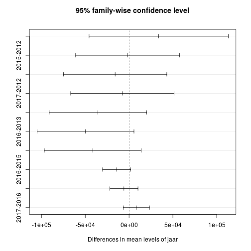

### Verdieping

- kunnen we zomaar de gemiddelden met elkaar vergelijken?
- is de verdeling normaal?

```r
ggplot(df_hyp)+
  aes(x=footprint)+
  geom_histogram(bins=50)
```

### Verdieping

- kunnen we zomaar de gemiddelden met elkaar vergelijken?
- is de verdeling normaal?

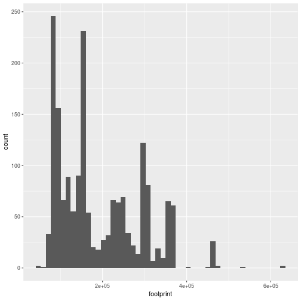

- **Nee** , Anova gaat uit van een normale verdeling

### Verdieping (2) - clusteren van footprints

- footprints clusteren om zo een cluster te maken van grote voertuigen (pakketbezorgerbusjes)
- algoritme k-means clustering – hoeveel clusters? **Elbow-method**

```r
df_cluster <- df_hyp %>%
  ungroup()%>%
  select(footprint)

df_scaled <- scale(df_cluster)
k.max <- 10
wss <- sapply(1:k.max, function(k)
   kmeans(x = df_scaled, centers = k, nstart = 10)$tot.withinss
)

df_results <- data.frame(k = 1:k.max, within_sum_square = wss)

ggplot(df_results) +
  geom_line(aes(x = k, y = within_sum_square)) +
  geom_vline(xintercept = 4, linetype = "dashed")
```

### Verdieping (2) - clusteren van footprints

- footprints clusteren om zo een cluster te maken van grote voertuigen (pakketbezorgerbusjes)
- algoritme k-means clustering – hoeveel clusters? **Elbow-method** => **4**

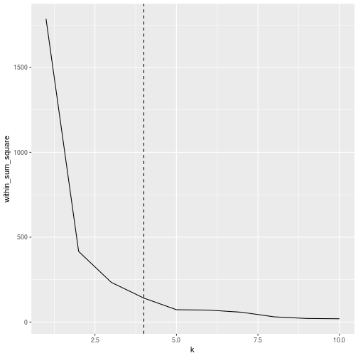

### Verdieping (3) - uitvoeren van clustering

** uitvoering van de clustering

```r
K <- 4
k_means <- kmeans(x=df_scaled, centers = sort(kmeans(x=df_scaled, centers = K)$centers))

df_hyp$footprint_cluster <- as.factor(k_means$cluster)

ggplot(df_hyp)+
  aes(x=footprint, fill=footprint_cluster, color=footprint_cluster)+
  geom_bar()
```

### Verdieping (3) - uitvoeren van clustering

** uitvoering van de clustering

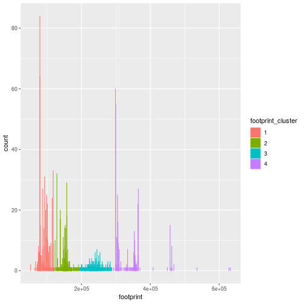

### Verdieping (4) - opnieuw valideren hypothese

Jaartallen vergelijken

- meerdere jaartallen(groepen)
- Chi-square op basis van aantallen in clusters i.p.v. gemiddelde footprint

```r
  table(df_hyp$jaar, df_hyp$footprint_cluster)
```

### Verdieping (4) - opnieuw valideren hypothese

Jaartallen vergelijken

- meerdere jaartallen(groepen)
- Chi-square op basis van aantallen in clusters i.p.v. gemiddelde footprint

```
         1   2   3   4
  2012   0  12   6   3
  2013   0   8   8   8
  2015 132 139  98 117
  2016 235 166  96 131
  2017 213 156 119 140
```

### Antwoord(2) - visueel

```r
df_hyp <- df_hyp %>%
  mutate(jaar_int = as.integer(jaar)) %>%
  ungroup()

ggplot(df_hyp) +
  aes(x=jaar_int, color=footprint_cluster)+
  geom_line(stat="count")+
  scale_y_continuous("Aantal ongelukken", labels = comma) +
  scale_x_continuous("Jaartal", breaks=c(2005:2018), labels=c(2005:2018) )
```

### Antwoord(2) - visueel

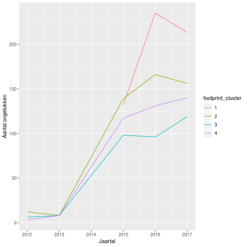

- stijging waarneembaar voor het cluster met grootste voertuigen
- **Wel bewijs voor de stelling**

### Antwoord(2) - statistisch

- Chi-square op basis van aantal ongelukken per jaar

```r
df_aov2 <- df_hyp %>%
  filter(jaar_int >= 2010 )%>%
  filter(footprint_cluster == 4 )%>%
  mutate(jaar = as.factor(year(DATUM)))%>%
  group_by(jaar) %>%
  summarise(aantal = n())

c <- chisq.test(df_aov2$aantal)
c
c$observed
round(c$expected,2)
```

### Antwoord(2) - statistisch

- Chi-square op basis van aantal ongelukken per jaar

```
    Chi-squared test for given probabilities

data:  df_aov2$aantal
X-squared = 234.12, df = 4, p-value < 2.2e-16
```

```
[1]   3   8 117 131 140
```

```
[1] 79.8 79.8 79.8 79.8 79.8
```

**Significant verschil tussen groepen(jaren)**  
**Duidelijke toename te zien in aantal ongevallen met voertuigen in de grootste categorie**

### Conclusie

**Op basis van de BRON dataset is te herleiden dat voertuigen met een grotere footprint de afgelopen jaren significant meer bij ongevallen betrokken zijn geweest bij ongelukken in 30 km-zones binnen de bebouwde kom vergeleken met eerdere jaartallen.**

### Vragen

**???**